# Daily Mood Ratings and Analysis

Andrew McCartney

2024-02-29

## Introduction

After about 120 days’ worth of ratings, I began to do deeper analyses on the data (which are almost all binary or essentially qualitative descriptions) to track trends in mood.

Beginning in February 2024, I turned the analyses I was running into a daily report that contains ongoing analyses so that after I input last night’s data, I can get all of my typical questions re-calculated at the click of a button.

## Data

Pull the data from excel and display the first few days.

```r
dat<-use("C:\\Users\\Andrew.Mccartney2\\Documents\\dailybean.xlsx")%>%
  mutate(date = ymd(date))
dat %>% glimpse()
```

```
## Rows: 125
## Columns: 24
## $ date                 <date> 2023-10-12, 2023-10-13, 2023-10-14, 2023-10-15, …
## $ rating               <dbl> 3, 2, 4, 3, 3, 1, 3, 2, 3, 3, 3, 2, 2, 4, 5, 1, 4…
## $ social_acquaintaince <dbl> 1, 1, 1, 0, 0, 0, 0, 0, 0, 0, 0, 1, 0, 0, 0, 0, 0…
## $ social_friend        <dbl> 0, 0, 1, 0, 0, 0, 1, 0, 0, 1, 0, 0, 0, 1, 1, 0, 1…
## $ social_family        <dbl> 0, 0, 0, 0, 0, 0, 0, 0, 1, 1, 0, 0, 0, 0, 0, 1, 0…
## $ social_none          <dbl> 0, 0, 0, 1, 1, 1, 0, 1, 0, 0, 1, 0, 1, 0, 0, 0, 0…
## $ weekday              <dbl> 5, 6, 7, 1, 2, 3, 4, 5, 6, 7, 1, 3, 4, 6, 1, 2, 3…
## $ holiday              <dbl> 0, 0, 0, 0, 0, 0, 0, 0, 0, 0, 0, 0, 0, 0, 0, 0, 1…
## $ feeling_excited      <dbl> 0, 0, 0, 0, 0, 0, 0, 0, 0, 0, 0, 0, 0, 1, 0, 0, 0…
## $ feeling_relaxed      <dbl> 0, 0, 0, 0, 0, 0, 0, 0, 1, 0, 0, 0, 0, 0, 0, 0, 0…
## $ feeling_proud        <dbl> 0, 0, 0, 0, 0, 0, 1, 0, 0, 0, 0, 0, 0, 0, 1, 0, 0…
## $ feeling_hopeful      <dbl> 0, 0, 1, 0, 0, 0, 0, 0, 0, 0, 0, 0, 0, 0, 0, 0, 0…
## $ feeling_happy        <dbl> 0, 0, 0, 0, 0, 0, 0, 0, 0, 0, 0, 0, 0, 0, 1, 0, 0…
## $ feeling_enthusiastic <dbl> 0, 0, 1, 0, 0, 0, 0, 0, 0, 0, 0, 0, 0, 1, 0, 0, 0…
## $ `feeling_pit-a-pat`  <dbl> 0, 0, 0, 0, 0, 0, 0, 0, 0, 0, 0, 0, 0, 1, 0, 0, 0…
## $ feeling_refreshed    <dbl> 0, 0, 0, 0, 0, 0, 0, 1, 0, 0, 0, 0, 0, 0, 0, 0, 0…
## $ feeling_gloomy       <dbl> 0, 0, 1, 0, 0, 1, 0, 0, 0, 0, 0, 1, 1, 0, 0, 0, 0…
## $ feeling_lonely       <dbl> 0, 1, 0, 0, 0, 0, 1, 1, 0, 0, 0, 0, 0, 0, 0, 1, 0…
## $ feeling_anxious      <dbl> 0, 0, 0, 1, 1, 1, 1, 0, 1, 0, 0, 0, 0, 1, 0, 1, 0…
## $ feeling_sad          <dbl> 0, 1, 0, 0, 0, 0, 1, 0, 0, 0, 0, 0, 0, 0, 0, 0, 0…
## $ feeling_angry        <dbl> 0, 0, 0, 0, 0, 1, 0, 0, 0, 0, 0, 0, 0, 0, 0, 1, 0…
## $ feeling_burdensome   <dbl> 1, 0, 0, 0, 0, 0, 0, 0, 0, 0, 0, 0, 0, 0, 0, 0, 0…
## $ feeling_annoyed      <dbl> 0, 0, 0, 0, 0, 0, 0, 0, 1, 0, 0, 0, 1, 0, 0, 1, 0…
## $ feeling_tired        <dbl> 0, 0, 1, 1, 1, 0, 0, 0, 0, 0, 1, 0, 1, 0, 0, 0, 1…
```

## Daily Mood Over Time

How has mood changed over time, in general? In this plot, I have also marked significant days and holidays as annotations; e.g. my trip to Colorado to see Katrina and Arielle as well as Valentines day, etc. The unmarked line at the end of January is my coffee date with Ashley. The unmarked line at the beginning of March is the anniversary of Laura’s text. In a previous version of this graph I “jittered” the points to give it more liveliness, but the jitters were obscuring the actual values of the ratings more than I wanted and adjusting them by functional arguments didn’t solve the problem to my liking.

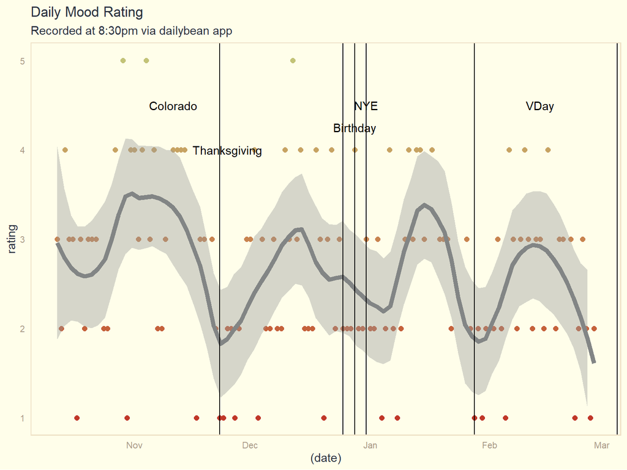

```r
dat %>%
  ggplot(aes(x=(date), y = rating,
             color = rating
             ))+
  geom_point(size = 2)+
  geom_smooth(span = 0.2, se = T, linewidth = 2, color = "#828585")+
  #coord_polar()+
  scale_x_date()+
  labs(title = "Daily Mood Rating",
       subtitle = "Recorded at 8:30pm via dailybean app")+
  annotate("text", x = mdy("11/25/23"), y = 4, label = "Thanksgiving")+
  annotate("text", x = mdy("11/11/23"), y = 4.5, label = "Colorado")+
  geom_vline(xintercept=mdy("11/23/23"))+
  geom_vline(xintercept = mdy("12/25/23"))+
  geom_vline(xintercept = mdy("12/31/23"))+
  geom_vline(xintercept = mdy("12/28/23"))+
  annotate("text", x = mdy("12/28/23"), y = 4.25, label= "Birthday")+
  scale_y_continuous(limits = c(1,5))+
  annotate('text', x = mdy("12/31/23"), y = 4.5, label="NYE")+
  geom_vline(xintercept = mdy("01/28/2024")) +
  geom_vline(xintercept = mdy("03/05/2024")) +
  annotate('text', x = mdy("02/14/2024"), y = 4.5, label = "VDay")+
  scale_color_gradient(low = "#C03728", high = "#c3c377")+
  theme_pomological()+
  guides(color = "none")+
  NULL
```

## Is there a cyclical effect?

As of February 2024, there appears to be a cyclical or sinusoidal pattern to my mood ratings. In this version of the plot, I have taken each month as a different factor and plotted its loess smoothed line, along with adding a grey line that indicates the loess smoothing of all of the months in the data set. There *does* appear to be a weak pattern of rise and fall peaking around the 10th of every month and falling around the 20th, but that’s probably just coincidences based on the fact that November and December both have holidays near the 20th of the month which depress scores.

More data are likely needed, at which point auto-regressive techniques might become necessary to determine real longterm patterns of growth.

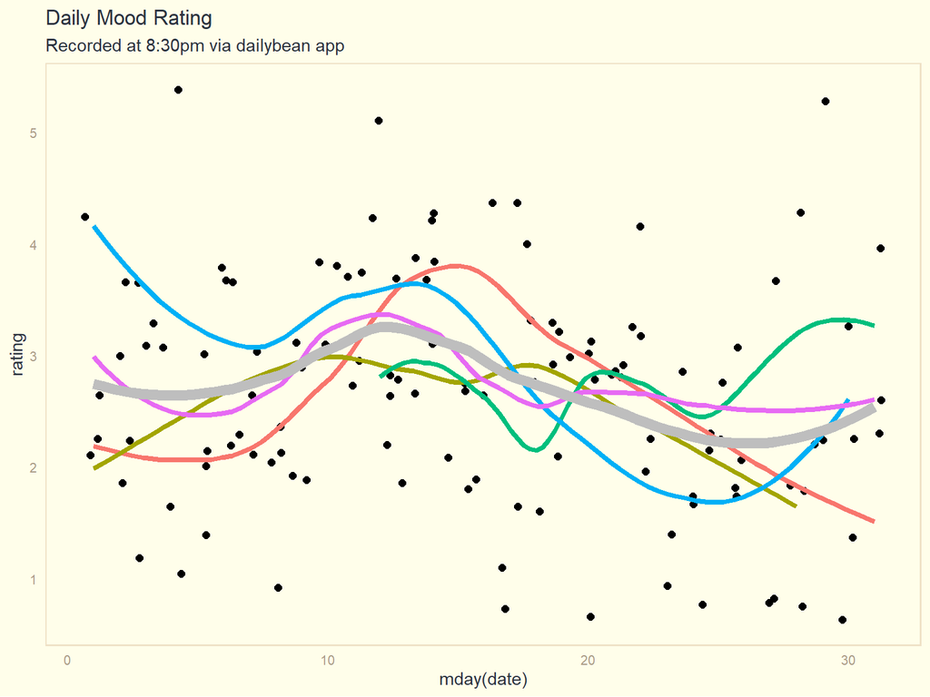

```r
  dat %>%
    ggplot(aes(x=mday(date), y = rating,
    ))+
    geom_jitter(size = 2)+
    geom_smooth(span = 0.6, se = F, linewidth = 1.5, aes(color = factor(month(date))))+
    geom_smooth(span = 0.6, se = F, linewidth = 3, color = "grey")+
    labs(title = "Daily Mood Rating",
       subtitle = "Recorded at 8:30pm via dailybean app")+
    theme_pomological()+
    guides(color = "none")+
    NULL
```

## Modeling

What can we learn from the data? Beware that linear modeling over these data is bound to be problematic given the aforementioned sinusoidal nature; however, even if there is no strong linear trend, controlling for time is probably still at least a little helpful. Other qualitative factors are included as listed.

### Data Description

```r
dat %>%
  mccrr::description(  )
```

Data Description

|  | n | mean | sd | min | max | range | se |
| --- | --- | --- | --- | --- | --- | --- | --- |
| date | 125 | NaN | NA | Inf | -Inf | -Inf | NA |
| rating | 125 | 2.66 | 1.00 | 1 | 5 | 4 | 0.09 |
| social_acquaintaince | 125 | 0.21 | 0.41 | 0 | 1 | 1 | 0.04 |
| social_friend | 125 | 0.29 | 0.45 | 0 | 1 | 1 | 0.04 |
| social_family | 125 | 0.14 | 0.34 | 0 | 1 | 1 | 0.03 |
| social_none | 125 | 0.46 | 0.50 | 0 | 1 | 1 | 0.04 |
| weekday | 125 | 3.95 | 2.06 | 1 | 7 | 6 | 0.18 |
| holiday | 125 | 0.05 | 0.21 | 0 | 1 | 1 | 0.02 |
| feeling_excited | 125 | 0.07 | 0.26 | 0 | 1 | 1 | 0.02 |
| feeling_relaxed | 125 | 0.16 | 0.37 | 0 | 1 | 1 | 0.03 |
| feeling_proud | 125 | 0.09 | 0.28 | 0 | 1 | 1 | 0.03 |
| feeling_hopeful | 125 | 0.15 | 0.36 | 0 | 1 | 1 | 0.03 |
| feeling_happy | 125 | 0.03 | 0.18 | 0 | 1 | 1 | 0.02 |
| feeling_enthusiastic | 125 | 0.06 | 0.25 | 0 | 1 | 1 | 0.02 |
| feeling_pit-a-pat | 125 | 0.04 | 0.20 | 0 | 1 | 1 | 0.02 |
| feeling_refreshed | 125 | 0.12 | 0.33 | 0 | 1 | 1 | 0.03 |
| feeling_gloomy | 125 | 0.21 | 0.41 | 0 | 1 | 1 | 0.04 |
| feeling_lonely | 125 | 0.15 | 0.36 | 0 | 1 | 1 | 0.03 |
| feeling_anxious | 125 | 0.57 | 0.50 | 0 | 1 | 1 | 0.04 |
| feeling_sad | 125 | 0.26 | 0.44 | 0 | 1 | 1 | 0.04 |
| feeling_angry | 125 | 0.17 | 0.38 | 0 | 1 | 1 | 0.03 |
| feeling_burdensome | 125 | 0.09 | 0.28 | 0 | 1 | 1 | 0.03 |
| feeling_annoyed | 125 | 0.18 | 0.39 | 0 | 1 | 1 | 0.03 |
| feeling_tired | 125 | 0.30 | 0.46 | 0 | 1 | 1 | 0.04 |

### Relationships

```r
dat %>%
  lm_robust(rating~date + holiday+ social_acquaintaince + social_friend+ social_family, data = .) -> m1

dat %>%
  lm_robust(rating~date + social_acquaintaince + social_friend+ social_family, data = .) -> m2

sjPlot::tab_model(m1, m2)
```

|  | rating |  |  | rating |  |  |
| --- | --- | --- | --- | --- | --- | --- |
| Predictors | Estimates | CI | p | Estimates | CI | p |
| (Intercept) | 89.15 | 12.82 – 165.47 | **0.022** | 90.77 | 15.20 – 166.33 | **0.019** |
| date | -0.00 | -0.01 – -0.00 | **0.026** | -0.00 | -0.01 – -0.00 | **0.022** |
| holiday | -0.26 | -0.76 – 0.24 | 0.300 |  |  |  |
| social acquaintaince | 0.21 | -0.25 – 0.67 | 0.360 | 0.21 | -0.24 – 0.67 | 0.359 |
| social friend | 0.96 | 0.61 – 1.32 | **<0.001** | 0.94 | 0.60 – 1.28 | **<0.001** |
| social family | -0.34 | -0.74 – 0.05 | 0.087 | -0.37 | -0.77 – 0.04 | 0.076 |
| Observations | 125 |  |  | 125 |  |  |
| R<sup>2</sup> / R<sup>2</sup> adjusted | 0.238 / 0.206 |  |  | 0.235 / 0.210 |  |  |

### Weekday

```r
dat %>%
   regress(rating ~ factor(weekday) + holiday)
```

|  | rating |  |  |
| --- | --- | --- | --- |
| Predictors | Estimates | CI | p |
| (Intercept) | 2.79 | 2.34 – 3.25 | **<0.001** |
| weekday2 | -0.42 | -1.08 – 0.25 | 0.215 |
| weekday3 | -0.25 | -0.94 – 0.45 | 0.488 |
| weekday4 | -0.24 | -0.84 – 0.36 | 0.432 |
| weekday5 | -0.11 | -0.77 – 0.54 | 0.732 |
| weekday6 | -0.22 | -0.86 – 0.43 | 0.510 |
| weekday7 | 0.26 | -0.39 – 0.91 | 0.427 |
| holiday | 0.11 | -0.81 – 1.04 | 0.812 |
| Observations | 125 |  |  |
| R<sup>2</sup> / R<sup>2</sup> adjusted | 0.041 / -0.016 |  |  |

## Emotions

What are my most common feelings? How often do I rate a day as having contained that emotion?

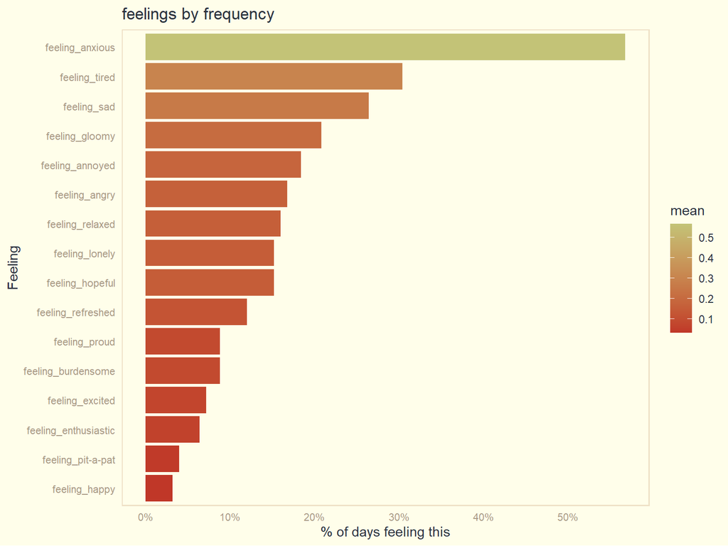

```r
means <- dat %>%
  summarize(across(where(is.numeric),  mean)) %>%
  t() %>%
  as.data.frame() %>%
  tibble::rownames_to_column() %>%
  as_tibble() %>%
  rename(variable = rowname, mean = V1)
feelings <- means %>%
  filter(str_detect(variable, "feeling"))
feelings %>%
  arrange(desc(mean)) %>%
  ggplot(aes(x = mean, y = fct_reorder(variable, mean), fill = mean)) +
  geom_col()+
  scale_x_continuous(labels = scales::percent, n.breaks = 10)+
  theme_pomological()+
  scale_fill_gradient(low = "#C03728", high = "#c3c377")+
  labs(
    title = "feelings by frequency",
    x = "% of days feeling this",
    y = "Feeling"
  )
```